# work_stanley

## Libraries

```r
library(tidyverse)
library(janitor)
library(ggplot2)
library(naniar)
library(ggmap)
library(shiny)
library(shinydashboard)
library(UKFE)
library(bslib)
```

## Data

We will use data from [William B.V. Langdon, Richard Fox, Owen T. Lewis, Host plant use is driven by microclimate not nutritional quality in a grassland butterfly](https://doi.org/10.1101/2025.11.15.688506). The original research article and data sets are included in the data folder in this repository.

```r
egg_laying <- read_csv("data/egg_laying_data.csv") %>%
  clean_names()
plant_chemistry <- read_csv("data/plant_chemistry_data.csv") %>%
  clean_names()
```

## Exploratory Data Analysis

**Looking Into Egg Laying Data Set**

```r
names(egg_laying)
```

```
##  [1] "predicted_n"             "n_se"
##  [3] "n_weights"               "plant_id"
##  [5] "id_number"               "species"
##  [7] "season"                  "n_eggs"
##  [9] "larvae"                  "occupied"
## [11] "gps"                     "bare_ground"
## [13] "veg"                     "litter"
## [15] "sward_height"            "plant_area"
## [17] "bare"                    "plant_size_1"
## [19] "plant_size_2"            "leaf1_length"
## [21] "leaf2_length"            "leaf3_length"
## [23] "leaf1_width"             "leaf2_width"
## [25] "leaf3_width"             "leaf1_area"
## [27] "leaf2_area"              "leaf3_area"
## [29] "total_leaf_area"         "leaves_sampled"
## [31] "average_leaf_size"       "temperature_soil"
## [33] "temperature_ambient"     "environment_date"
## [35] "temperature_date"        "date_mean_soil"
## [37] "date_sd_soil"            "temperature_soil_scaled"
## [39] "scaled_leaf_size"        "scaled_n_content"
```

```r
summary(egg_laying) # look at overall distribution of data, check for abnormal values
```

```
##   predicted_n        n_se          n_weights        plant_id
##  Min.   :1241   Min.   : 74.27   Min.   :0.5746   Length:318
##  1st Qu.:1412   1st Qu.: 94.58   1st Qu.:0.9424   Class :character
##  Median :1529   Median :103.48   Median :1.0118   Mode  :character
##  Mean   :1592   Mean   :104.69   Mean   :1.0197
##  3rd Qu.:1717   3rd Qu.:111.09   3rd Qu.:1.1070
##  Max.   :2585   Max.   :182.20   Max.   :1.4096
##
##    id_number        species             season              n_eggs
##  Min.   :  1.00   Length:318         Length:318         Min.   : 0.000
##  1st Qu.: 44.25   Class :character   Class :character   1st Qu.: 0.000
##  Median : 87.00   Mode  :character   Mode  :character   Median : 0.000
##  Mean   : 92.38                                         Mean   : 1.069
##  3rd Qu.:141.75                                         3rd Qu.: 1.000
##  Max.   :187.00                                         Max.   :16.000
##
##      larvae          occupied       gps             bare_ground
##  Min.   :0.0000   Min.   :0.0   Length:318         Min.   :  0.00
##  1st Qu.:0.0000   1st Qu.:0.0   Class :character   1st Qu.:  0.00
##  Median :0.0000   Median :0.5   Mode  :character   Median :  0.00
##  Mean   :0.2296   Mean   :0.5                      Mean   : 10.15
##  3rd Qu.:0.0000   3rd Qu.:1.0                      3rd Qu.: 20.00
##  Max.   :7.0000   Max.   :1.0                      Max.   :100.00
##                                                    NA's   :1
##       veg            litter       sward_height      plant_area
##  Min.   :  0.0   Min.   : 0.00   Min.   : 0.000   Min.   :  3.75
##  1st Qu.: 88.0   1st Qu.: 0.00   1st Qu.: 7.375   1st Qu.: 50.25
##  Median :100.0   Median : 0.00   Median :16.000   Median : 98.00
##  Mean   : 92.9   Mean   : 8.36   Mean   :17.141   Mean   :128.13
##  3rd Qu.:100.0   3rd Qu.:16.00   3rd Qu.:27.000   3rd Qu.:165.00
##  Max.   :100.0   Max.   :56.00   Max.   :70.000   Max.   :672.00
##  NA's   :1       NA's   :1       NA's   :2
##      bare            plant_size_1    plant_size_2     leaf1_length
##  Length:318         Min.   : 1.50   Min.   : 1.500   Min.   :11.00
##  Class :character   1st Qu.: 8.00   1st Qu.: 6.000   1st Qu.:25.25
##  Mode  :character   Median :11.00   Median : 8.000   Median :34.00
##                     Mean   :11.78   Mean   : 9.417   Mean   :35.89
##                     3rd Qu.:15.00   3rd Qu.:12.000   3rd Qu.:44.00
##                     Max.   :35.00   Max.   :28.000   Max.   :87.00
##
```

[output cut: 25 more lines]

```
##  Min.   :14.0        Length:318         Length:318         Min.   :17.79
##  1st Qu.:17.0        Class :character   Class :character   1st Qu.:18.58
##  Median :24.0        Mode  :character   Mode  :character   Median :30.59
##  Mean   :21.2                                              Mean   :28.98
##  3rd Qu.:24.5                                              3rd Qu.:36.88
##  Max.   :27.0                                              Max.   :41.37
##
##   date_sd_soil    temperature_soil_scaled scaled_leaf_size  scaled_n_content
##  Min.   :0.5882   Min.   :-2.55332        Min.   :-1.2775   Min.   :-1.3718
##  1st Qu.:2.0652   1st Qu.:-0.80731        1st Qu.:-0.6556   1st Qu.:-0.7020
##  Median :3.5344   Median : 0.04203        Median :-0.2939   Median :-0.2478
##  Mean   :3.5259   Mean   : 0.00000        Mean   : 0.0000   Mean   : 0.0000
##  3rd Qu.:5.4793   3rd Qu.: 0.58461        3rd Qu.: 0.3826   3rd Qu.: 0.4859
##  Max.   :6.5102   Max.   : 2.90706        Max.   : 4.0953   Max.   : 3.8728
##
```

```r
egg_laying %>%
  miss_var_summary() #check for NA's
```

```
## # A tibble: 40 × 3
##    variable         n_miss pct_miss
##    <chr>             <int>    <num>
##  1 environment_date    170   53.5
##  2 leaf3_length         72   22.6
##  3 leaf3_width          72   22.6
##  4 leaf3_area           72   22.6
##  5 leaf2_length         12    3.77
##  6 leaf2_width          12    3.77
##  7 leaf2_area           12    3.77
##  8 sward_height          2    0.629
##  9 gps                   1    0.314
## 10 bare_ground           1    0.314
## # ℹ 30 more rows
```

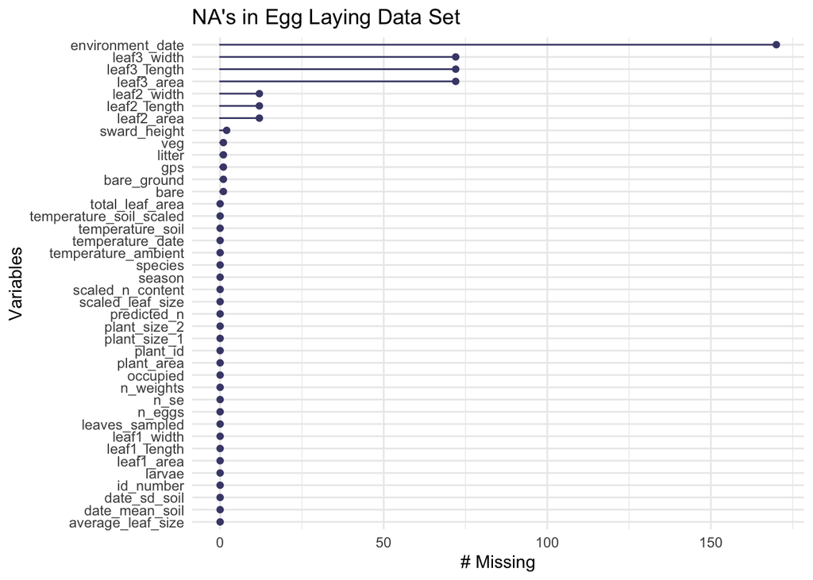

```r
egg_laying %>%
  gg_miss_var()+ #visualizing the NA's
  labs(title="NA's in Egg Laying Data Set")
```

**Looking Into Plant Chemistry Data Set**

```r
names(plant_chemistry)
```

```
##  [1] "plant_id"          "n"                 "c"
##  [4] "cn_percent"        "n_molar"           "c_molar"
##  [7] "cn_molar"          "plant_size_1"      "plant_size_2"
## [10] "plant_area"        "leaf1_length"      "leaf1_width"
## [13] "leaf2_length"      "leaf2_width"       "leaf3_length"
## [16] "leaf3_width"       "leaf1_area"        "leaf2_area"
## [19] "leaf3_area"        "total_leaf_area"   "leaves_sampled"
## [22] "average_leaf_size" "season"            "quality_pc1"
## [25] "quality_pc2"
```

```r
summary(plant_chemistry)
```

```
##    plant_id               n               c           cn_percent
##  Length:58          Min.   :0.982   Min.   :34.82   Min.   : 9.64
##  Class :character   1st Qu.:2.010   1st Qu.:43.56   1st Qu.:13.98
##  Mode  :character   Median :2.541   Median :44.92   Median :17.72
##                     Mean   :2.543   Mean   :44.40   Mean   :19.22
##                     3rd Qu.:3.119   3rd Qu.:45.89   3rd Qu.:22.65
##                     Max.   :4.385   Max.   :47.89   Max.   :44.57
##     n_molar          c_molar         cn_molar      plant_size_1
##  Min.   : 701.1   Min.   :28990   Min.   :11.24   Min.   : 2.00
##  1st Qu.:1435.2   1st Qu.:36265   1st Qu.:16.31   1st Qu.:12.00
##  Median :1813.8   Median :37403   Median :20.67   Median :16.00
##  Mean   :1815.8   Mean   :36968   Mean   :22.41   Mean   :16.51
##  3rd Qu.:2227.0   3rd Qu.:38207   3rd Qu.:26.41   3rd Qu.:20.00
##  Max.   :3130.6   Max.   :39872   Max.   :51.98   Max.   :38.00
##   plant_size_2     plant_area     leaf1_length    leaf1_width
##  Min.   : 3.00   Min.   :  6.0   Min.   :12.00   Min.   : 8.00
##  1st Qu.: 9.00   1st Qu.:113.2   1st Qu.:32.75   1st Qu.:17.25
##  Median :13.00   Median :202.5   Median :45.50   Median :22.00
##  Mean   :13.56   Mean   :253.6   Mean   :45.76   Mean   :22.69
##  3rd Qu.:18.75   3rd Qu.:363.4   3rd Qu.:56.50   3rd Qu.:27.00
##  Max.   :27.00   Max.   :874.0   Max.   :87.00   Max.   :47.00
##   leaf2_length    leaf2_width     leaf3_length    leaf3_width
##  Min.   :14.00   Min.   :10.00   Min.   :12.00   Min.   : 4.00
##  1st Qu.:33.00   1st Qu.:17.00   1st Qu.:29.00   1st Qu.:14.00
##  Median :40.00   Median :22.00   Median :37.00   Median :20.00
##  Mean   :43.07   Mean   :22.69   Mean   :40.33   Mean   :21.28
##  3rd Qu.:53.50   3rd Qu.:27.00   3rd Qu.:52.00   3rd Qu.:27.75
##  Max.   :98.00   Max.   :62.00   Max.   :82.00   Max.   :43.00
##    leaf1_area       leaf2_area       leaf3_area   total_leaf_area
##  Min.   :  96.0   Min.   : 165.0   Min.   :  52   Min.   : 357
##  1st Qu.: 553.8   1st Qu.: 556.5   1st Qu.: 401   1st Qu.:1702
##  Median :1047.5   Median : 948.0   Median : 710   Median :2785
##  Mean   :1160.8   Mean   :1080.3   Mean   : 975   Mean   :3216
##  3rd Qu.:1365.2   3rd Qu.:1338.0   3rd Qu.:1456   3rd Qu.:4453
##  Max.   :3741.0   Max.   :3822.0   Max.   :3526   Max.   :7715
##  leaves_sampled average_leaf_size    season           quality_pc1
##  Min.   :3      Min.   : 119.0    Length:58          Min.   :-5.5768
##  1st Qu.:3      1st Qu.: 567.2    Class :character   1st Qu.:-2.3222
##  Median :3      Median : 928.3    Mode  :character   Median :-1.0509
##  Mean   :3      Mean   :1072.0                       Mean   :-1.2448
##  3rd Qu.:3      3rd Qu.:1484.3                       3rd Qu.: 0.2339
##  Max.   :3      Max.   :2571.7                       Max.   : 1.5547
##   quality_pc2
##  Min.   :-1.75139
##  1st Qu.:-0.50397
##  Median : 0.01885
##  Mean   : 0.11307
##  3rd Qu.: 0.45767
##  Max.   : 2.94627
```

```r
plant_chemistry %>%
  miss_var_summary() #check for NA's
```

```
## # A tibble: 25 × 3
##    variable     n_miss pct_miss
##    <chr>         <int>    <num>
##  1 plant_id          0        0
##  2 n                 0        0
##  3 c                 0        0
##  4 cn_percent        0        0
##  5 n_molar           0        0
##  6 c_molar           0        0
##  7 cn_molar          0        0
##  8 plant_size_1      0        0
##  9 plant_size_2      0        0
## 10 plant_area        0        0
## # ℹ 15 more rows
```

The data set, plant_chemistry, is clean and tidy without any NA’s or suspicious values.

**Joining the Data Sets**

Since the egg_laying and plant_chemistry data sets have the same plant id, we can join the two data sets together using a join function in case we want to use variables of a plant id from both data sets. It’s important to know that plant_chemistry also shares the same leaf length, width, area, plant area, and season, so we can select the unique variables of plant_chemistry.

```r
plant_joined <- left_join(egg_laying, plant_chemistry %>% select(plant_id, n, c, cn_percent, n_molar, c_molar, cn_molar, quality_pc1, quality_pc2), by="plant_id")
```

**Distribution of Important Variables**

```r
plant_joined %>%
  select(season) %>%
  count(season, sort=T)
```

```
## # A tibble: 2 × 2
##   season     n
##   <chr>  <int>
## 1 spring   184
## 2 autumn   134
```

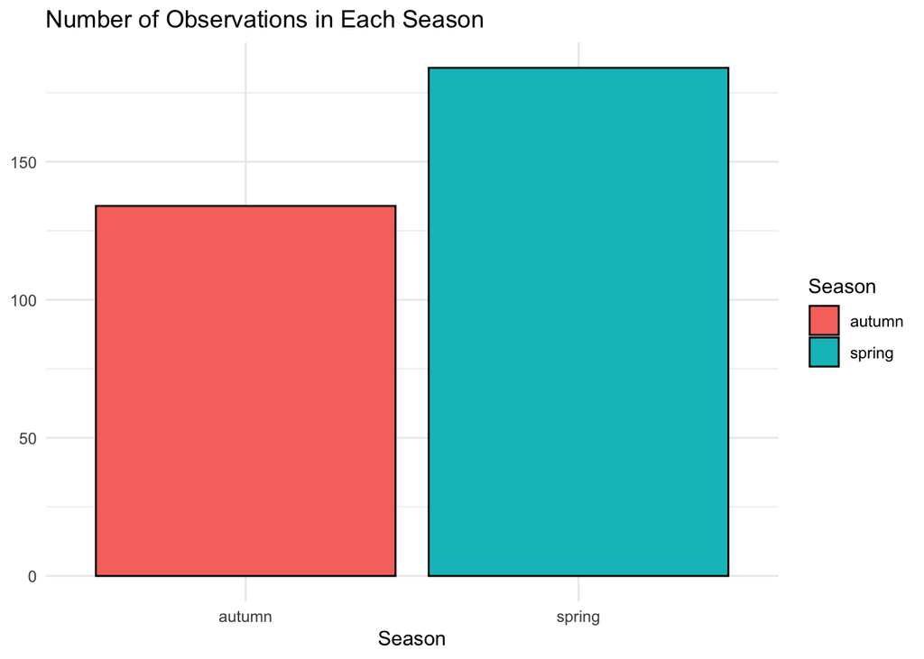

```r
plant_joined %>%
  select(season) %>%
  ggplot(aes(x=season))+
  geom_bar(aes(fill=season), color="black")+
  labs(title="Number of Observations in Each Season", x="Season", y=NULL, fill="Season")+
  theme_minimal()
```

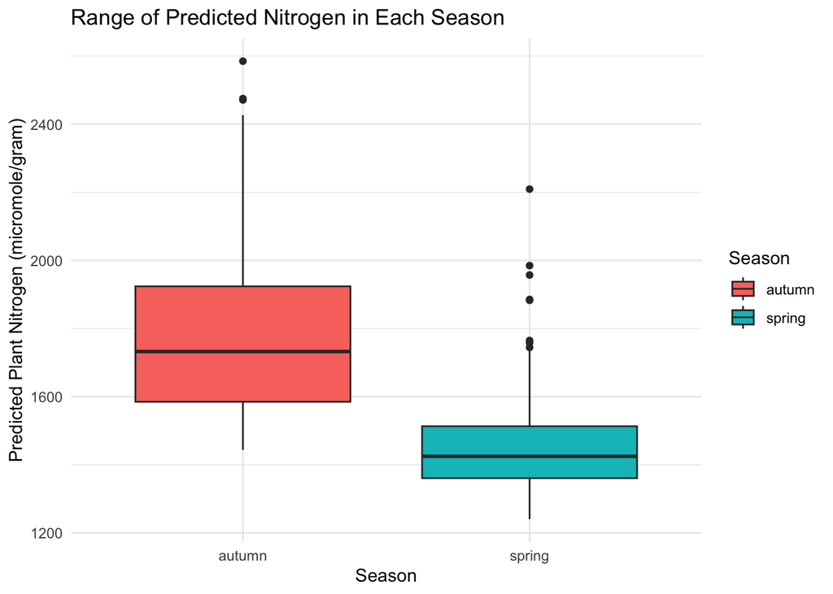

```r
plant_joined %>%
  select(season, predicted_n) %>%
  ggplot(aes(x=season, y=predicted_n))+
  geom_boxplot(aes(fill=season))+
  labs(title="Range of Predicted Nitrogen in Each Season", x="Season", y="Predicted Plant Nitrogen (micromole/gram)", fill="Season")+
  theme_minimal()
```

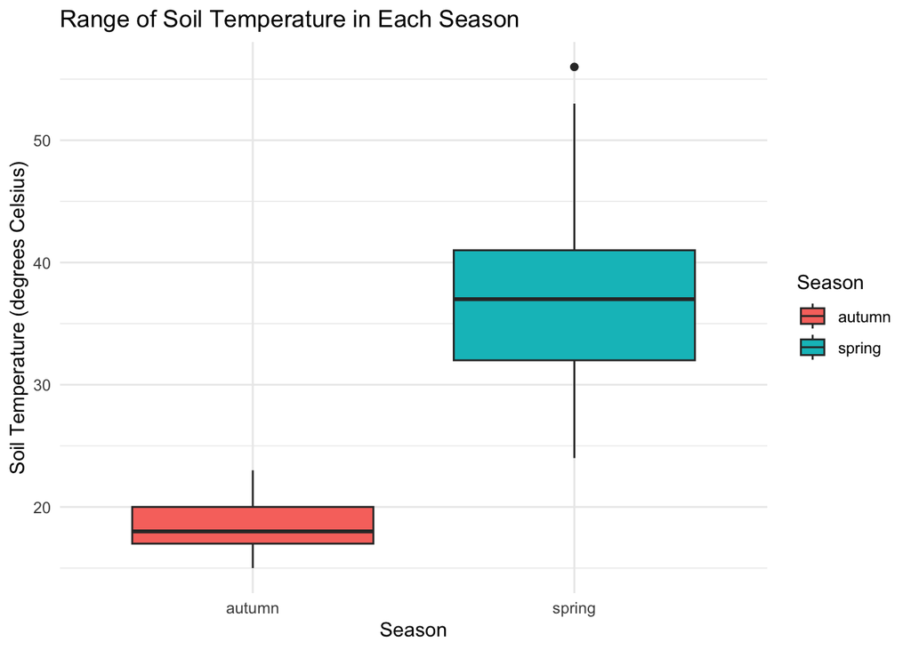

```r
plant_joined %>%
  select(season, temperature_soil) %>%
  ggplot(aes(x=season, y=temperature_soil))+
  geom_boxplot(aes(fill=season))+
  labs(title="Range of Soil Temperature in Each Season", x="Season", y="Soil Temperature (degrees Celsius)", fill="Season")+
  theme_minimal()
```

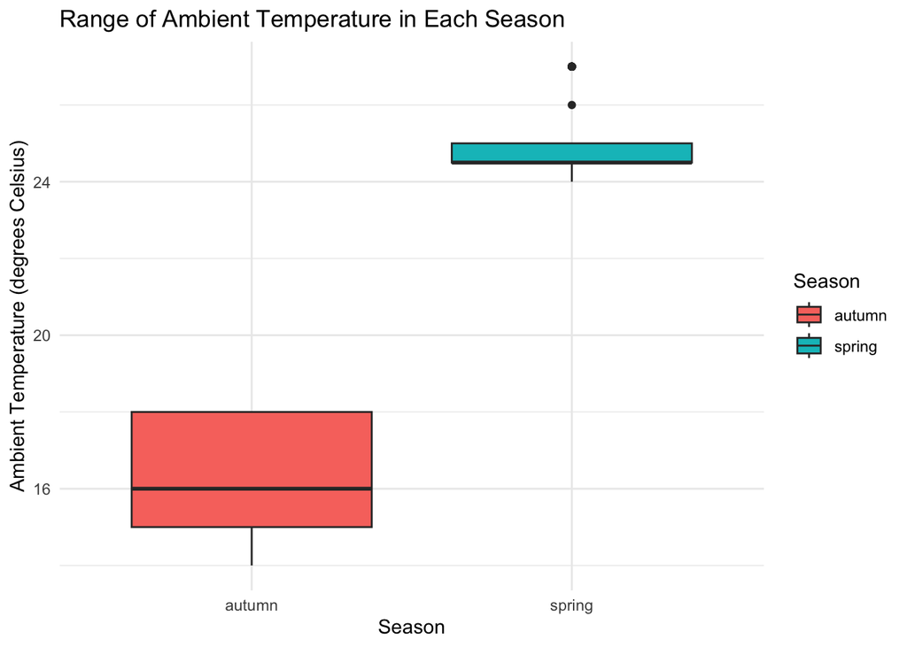

```r
plant_joined %>%
  select(season, temperature_ambient) %>%
  ggplot(aes(x=season, y=temperature_ambient))+
  geom_boxplot(aes(fill=season))+
  labs(title="Range of Ambient Temperature in Each Season", x="Season", y="Ambient Temperature (degrees Celsius)", fill="Season")+
  theme_minimal()
```

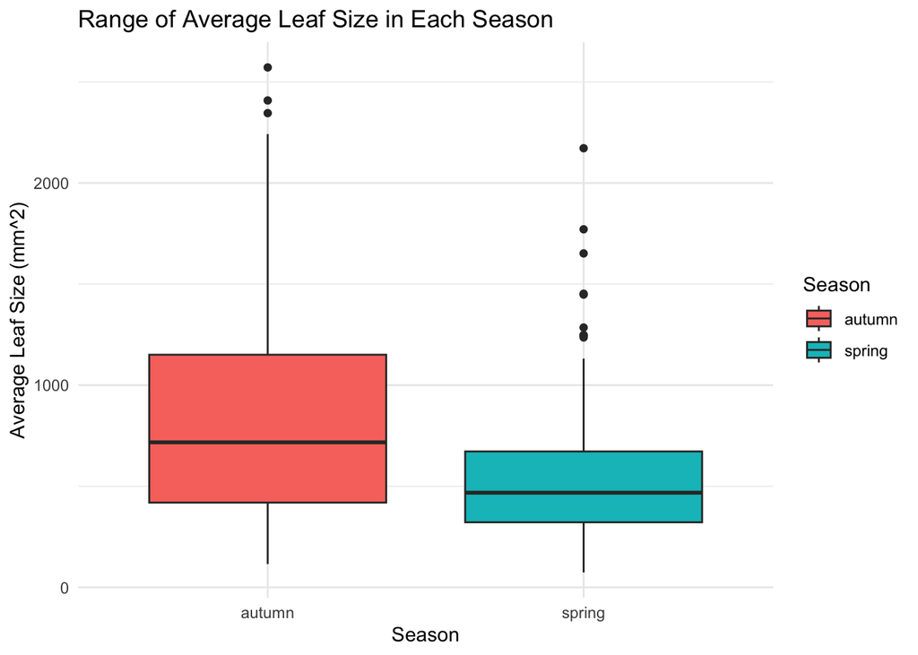

```r
plant_joined %>%
  select(season, average_leaf_size) %>%
  ggplot(aes(x=season, y=average_leaf_size))+
  geom_boxplot(aes(fill=season))+
  labs(title="Range of Average Leaf Size in Each Season", x="Season", y="Average Leaf Size (mm^2)", fill="Season")+
  theme_minimal()
```

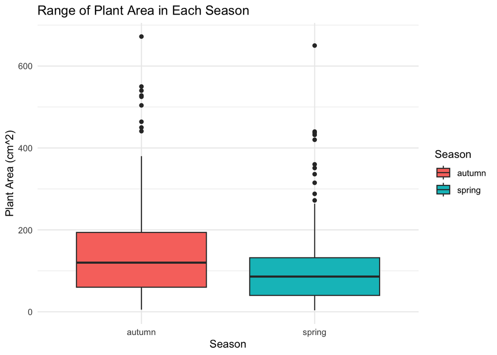

```r
plant_joined %>%
  select(season, plant_area) %>%
  ggplot(aes(x=season, y=plant_area))+
  geom_boxplot(aes(fill=season))+
  labs(title="Range of Plant Area in Each Season", x="Season", y="Plant Area (cm^2)", fill="Season")+
  theme_minimal()
```

**Interpreting Paper’s Principal Component Analysis**

Principal Component Analysis is a dimension-reducing strategy that converts highly correlated variables into non-correlated variables called “principal components”. These principal components retain the original data set’s variability. Our data set comes with two variables, quality_PC1 and quality_PC2, which are values of principal components that the researchers of the paper got to represent average leaf size and plant size. We can attempt to visualize the principal components’ relationships to other variables.

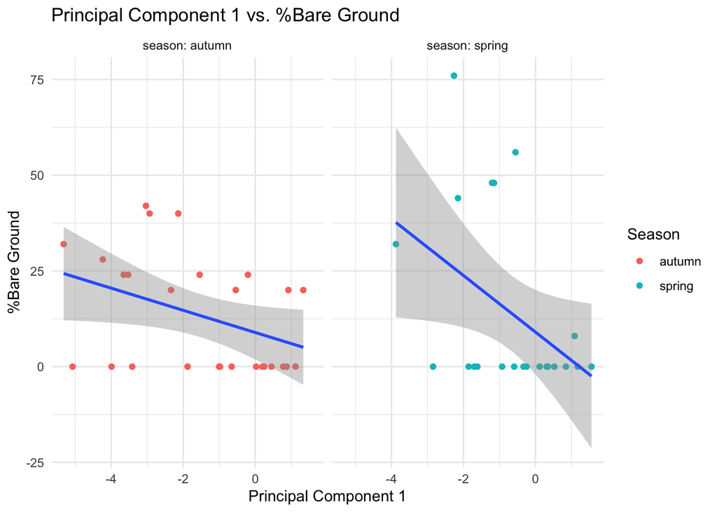

```r
plant_joined %>%
  select(bare_ground, quality_pc1, season) %>%
  na.omit() %>%
  ggplot(aes(x=quality_pc1, y=bare_ground))+
  geom_point(aes(color=season))+
  geom_smooth(method="lm", se=T)+
  facet_wrap(~season, ncol=2, labeller=label_both)+
  labs(title="Principal Component 1 vs. %Bare Ground", x="Principal Component 1", y="%Bare Ground", color="Season")+
  theme_minimal()
```

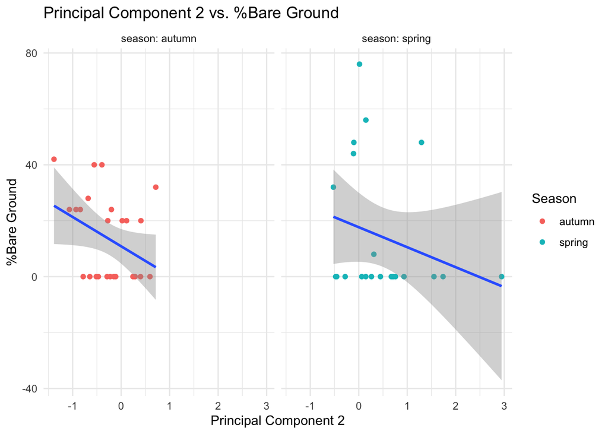

```r
plant_joined %>%
  select(bare_ground, quality_pc2, season) %>%
  na.omit() %>%
  ggplot(aes(x=quality_pc2, y=bare_ground))+
  geom_point(aes(color=season))+
  geom_smooth(method="lm", se=T)+
  facet_wrap(~season, ncol=2, labeller=label_both)+
  labs(title="Principal Component 2 vs. %Bare Ground", x="Principal Component 2", y="%Bare Ground", color="Season")+
  theme_minimal()
```

From these plots, we can see that bare ground percentage is negatively correlated with both principal components relating to the average plant and leaf size.

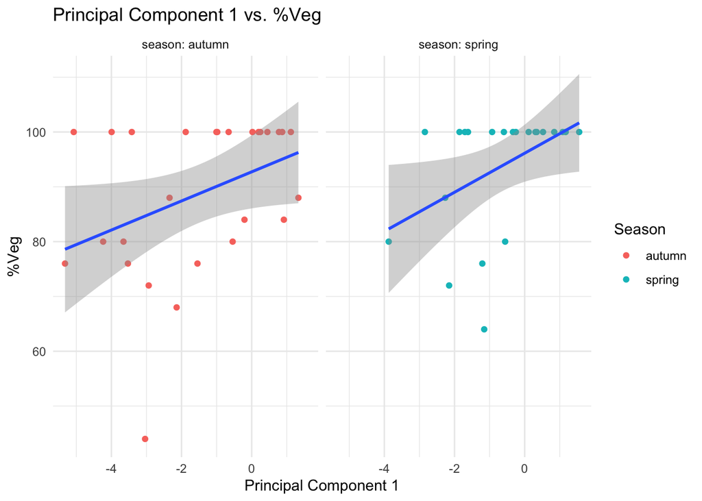

```r
plant_joined %>%
  select(veg, quality_pc1, season) %>%
  na.omit() %>%
  ggplot(aes(x=quality_pc1, y=veg))+
  geom_point(aes(color=season))+
  geom_smooth(method="lm", se=T)+
  facet_wrap(~season, ncol=2, labeller=label_both)+
  labs(title="Principal Component 1 vs. %Veg", x="Principal Component 1", y="%Veg", color="Season")+
  theme_minimal()
```

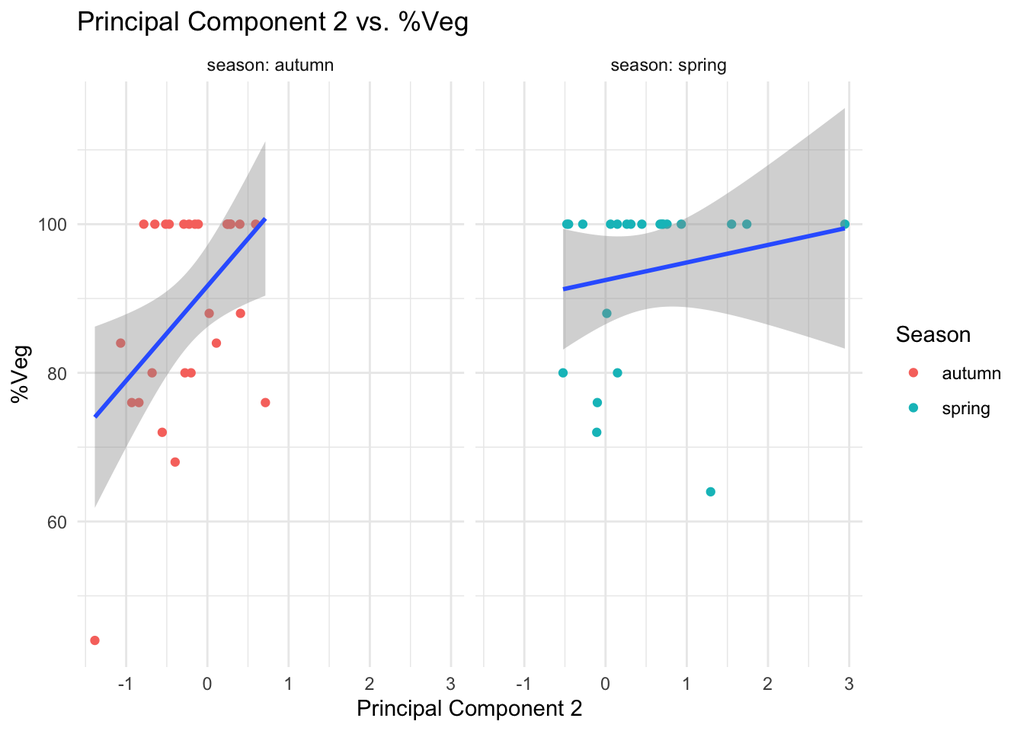

```r
plant_joined %>%
  select(veg, quality_pc2, season) %>%
  na.omit() %>%
  ggplot(aes(x=quality_pc2, y=veg))+
  geom_point(aes(color=season))+
  geom_smooth(method="lm", se=T)+
  facet_wrap(~season, ncol=2, labeller=label_both)+
  labs(title="Principal Component 2 vs. %Veg", x="Principal Component 2", y="%Veg", color="Season")+
  theme_minimal()
```

From these plots, we see that vegetation percentage is positively correlated with both principal components.

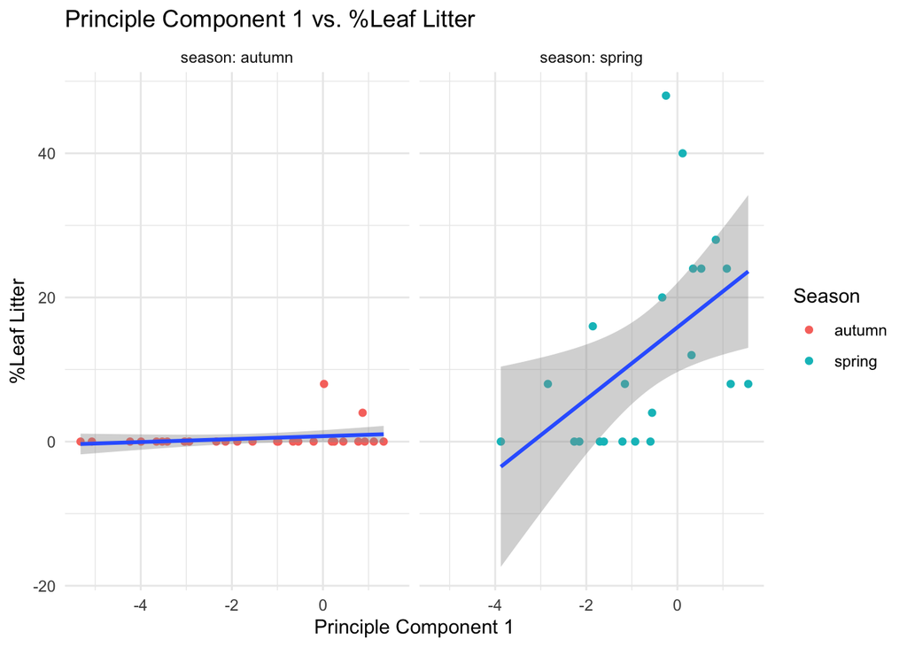

```r
plant_joined %>%
  select(litter, quality_pc1, season) %>%
  na.omit() %>%
  ggplot(aes(x=quality_pc1, y=litter))+
  geom_point(aes(color=season))+
  geom_smooth(method="lm", se=T)+
  facet_wrap(~season, ncol=2, labeller=label_both)+
  labs(title="Principle Component 1 vs. %Leaf Litter", x="Principle Component 1", y="%Leaf Litter", color="Season")+
  theme_minimal()
```

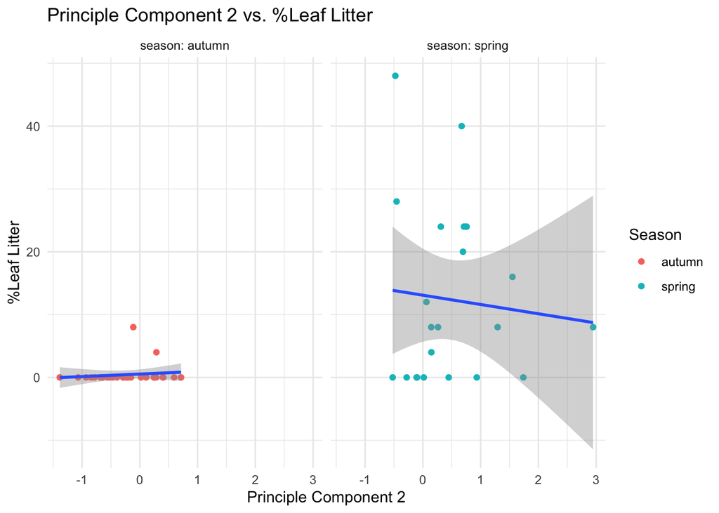

```r
plant_joined %>%
  select(litter, quality_pc2, season) %>%
  na.omit() %>%
  ggplot(aes(x=quality_pc2, y=litter))+
  geom_point(aes(color=season))+
  geom_smooth(method="lm", se=T)+
  facet_wrap(~season, ncol=2, labeller=label_both)+
  labs(title="Principle Component 2 vs. %Leaf Litter", x="Principle Component 2", y="%Leaf Litter", color="Season")+
  theme_minimal()
```

Interestingly, we don’t see the same consistent correlations with surrounding leaf litter percentage against both principle components. We see that in autumn, the litter percentage has no correlation between principle component 1 and 2 while in spring, the litter percentage is postive correlated with principle component 1 and negatively correlated with principle component 2.

**Creating Map for Data Set**

```r
register_stadiamaps("f9de653c-55a3-4f5b-9672-63291557e012", write = FALSE) # will probably take this down after repository check
coordtomap <- egg_laying %>%
  select(gps, season) %>%
  na.omit() %>%
  separate(gps, into=c("SP", "grid"), sep=2) %>% # separate numerical part from SP
  separate(grid, into=c("easting", "northing"), sep=5) %>% # divide number into easting and northing portions
  mutate(easting=as.numeric(easting)+400000) %>% # convert easting into latitude
  mutate(northing=as.numeric(northing)+200000) %>% #convert nothing into longitude
  rowwise() %>% # treat rows as separate groups in order to apply the ConvertGridRef to each row
  mutate(coords=list(ConvertGridRef(c(easting,northing)))) %>%
  unnest(coords) # converts latitude and longitude from the list as separate variables
```

```r
summary(coordtomap) # find the minimum and maximum latitude and longitude
```

```
##       SP               easting          northing         season
##  Length:317         Min.   :456341   Min.   :205384   Length:317
##  Class :character   1st Qu.:456412   1st Qu.:205426   Class :character
##  Mode  :character   Median :456460   Median :205514   Mode  :character
##                     Mean   :456478   Mean   :205503
##                     3rd Qu.:456551   3rd Qu.:205578
##                     Max.   :456611   Max.   :205614
##     latitude       longitude
##  Min.   :51.74   Min.   :-1.185
##  1st Qu.:51.74   1st Qu.:-1.184
##  Median :51.75   Median :-1.184
##  Mean   :51.75   Mean   :-1.183
##  3rd Qu.:51.75   3rd Qu.:-1.182
##  Max.   :51.75   Max.   :-1.181
```

```r
lat <- c(51.74 , 51.75) #
long <- c(-1.185 , -1.181)
bbox <- make_bbox(long, lat, f=0.25) # create bounding box
map1 <- get_stadiamap(bbox, maptype="stamen_terrain", zoom=15)
```

```
## ℹ © Stadia Maps © Stamen Design © OpenMapTiles © OpenStreetMap contributors.
```

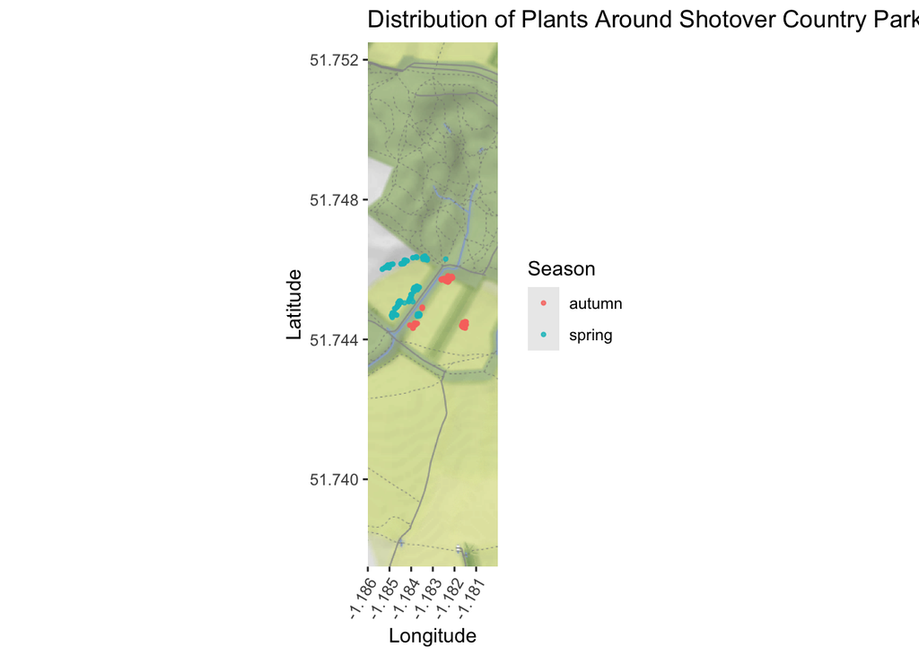

```r
ggmap(map1)+ # creating the map itself
  geom_point(data=coordtomap, aes(longitude, latitude, color=season), size=0.75, alpha=0.8)+
  theme(axis.text.x=element_text(angle=60, hjust=1))+
  labs(title="Distribution of Plants Around Shotover Country Park (United Kingdom)", x="Longitude", y="Latitude", color="Season")
```

## Factors Associated with Plant Nutritional Quality

Plant nutritional quality is dependent on the chemical composition of each plant, with butterflies usually benefiting from high nitrogen-containing plants so that they don’t need to overeat to obtain sufficient nutrients. Plant nitrogen is also representative of its soil nitrogen and improves plant growth in the vicinity. Therefore, having high nitrogen would lead to taller plants which then would lead to a lower soil temperature because less sun is able to reach the bottom of plants.

We can check to see if each of these correlations are true. We should expect to see a positive association between plant nitrogen and percent of vegetation around a plant, a positive association between plant nitrogen and sward height, which is the height that approximately 80% of plants grew at, and a negative association between predicted plant nitrogen and soil temperature.

**Plot of Predicted Plant Nitrogen vs. %Vegetation**

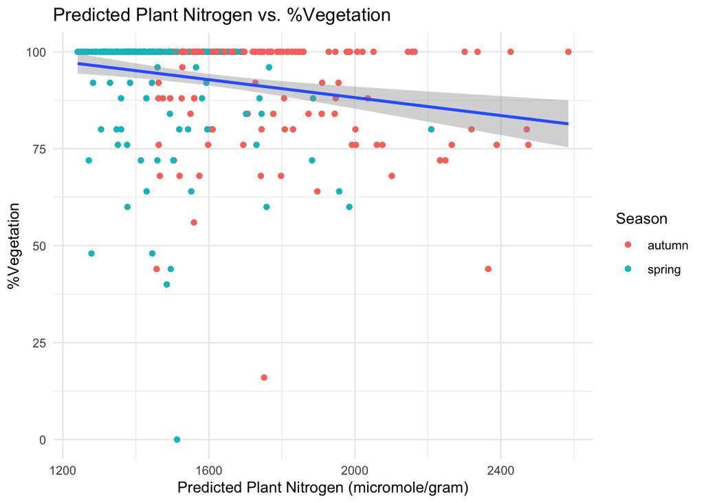

```r
plant_joined %>%
  select(predicted_n, veg, season) %>%
  na.omit() %>%
  ggplot(aes(x=predicted_n, y=veg))+
  geom_point(mapping=aes(color=season))+
  geom_smooth(method="lm", se=T)+
  labs(title="Predicted Plant Nitrogen vs. %Vegetation", x="Predicted Plant Nitrogen (micromole/gram)", y="%Vegetation", color="Season")+
  theme_minimal()
```

**Plot of Predicted Plant Nitrogen vs. Sward Height**

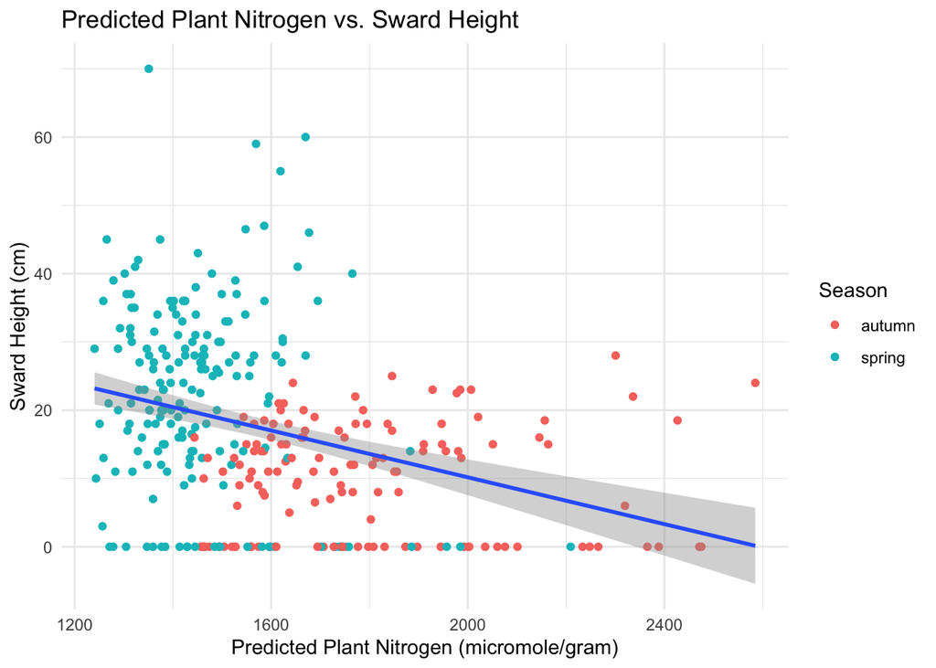

```r
plant_joined %>%
  select(predicted_n, sward_height, season) %>%
  na.omit() %>%
  ggplot(aes(x=predicted_n, y=sward_height))+
  geom_point(mapping=aes(color=season))+
  geom_smooth(method="lm", se=T)+
  labs(title="Predicted Plant Nitrogen vs. Sward Height", x="Predicted Plant Nitrogen (micromole/gram)", y="Sward Height (cm)", color="Season")+
  theme_minimal()
```

**Plot of Predicted Plant Nitrogen vs. Soil Temperature**

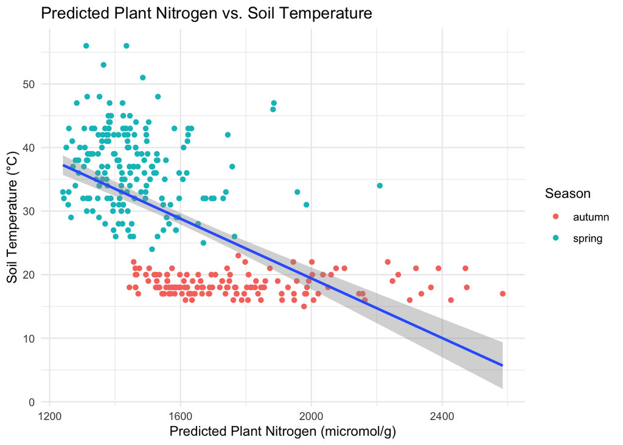

```r
plant_joined %>%
  select(predicted_n, temperature_soil, season) %>%
  na.omit() %>%
  ggplot(aes(x=predicted_n, y=temperature_soil))+
  geom_point(mapping=aes(color=season))+
  geom_smooth(method="lm", se=T)+
  labs(title="Predicted Plant Nitrogen vs. Soil Temperature", x="Predicted Plant Nitrogen (micromol/g)", y="Soil Temperature (°C)", color="Season")+
  theme_minimal()
```

**Discussion About Vegetation-Related Plant Nitrogen Plots**